# Sentiment-Analysis

Deepanshu Goyal

December 18, 2019

```r
rm(list=ls())
source('https://raw.githubusercontent.com/deepanshu-goyal/Text-Analytics/master/Common_Functions.R')

if (!require(qdap)) {install.packages("qdap")}
if(!require(textdata)) {install.packages("textdata")}
if(!require(ggraph)) {install.packages("ggraph")}
if(!require(ldatuning)) {install.packages("ldatuning")}
if (!require(udpipe)){install.packages("udpipe")}

library(qdap)
library(sentimentr)
library(tidytext)
library(ggraph)
library(igraph)
library(topicmodels)
library(ldatuning)
library(udpipe)
```

## Step 1: Read data from csv file and seperate reviews for Seltos, Compass & Hector

```r
setwd(getwd())
data = read.csv('seltos_hector_compass_reviews.csv')
seltos = data %>% filter(Brand=="Kia Seltos")
compass = data %>% filter(Brand =="Jeep Compass")
hector = data %>% filter(Brand== "MG Hector")

seltos_review = tolower(as.character(seltos$Review))
Compass_review = tolower(as.character(compass$Review))
hector_review = tolower(as.character(hector$Review))


review_df = data_frame(brand = tolower(as.character(data$Brand)),review = tolower(as.character(data$Review)))
review_dtm = create_dtm(data)
review_bow = review_df %>% group_by(brand) %>% mutate(doc_id=row_number()) %>% ungroup() %>% unnest_tokens(word,review)
```

## Step 2: Find out key Features/Topics in a corpus

Option1: Using word frequency, bigrams & COG graphs Option2: Using Nouns or Noun Phrases Option3: using Topic modeling techniques such as LDA Option4: using clustering technique - k means

Option1: Use bigrams & graphs (COG, igraph)

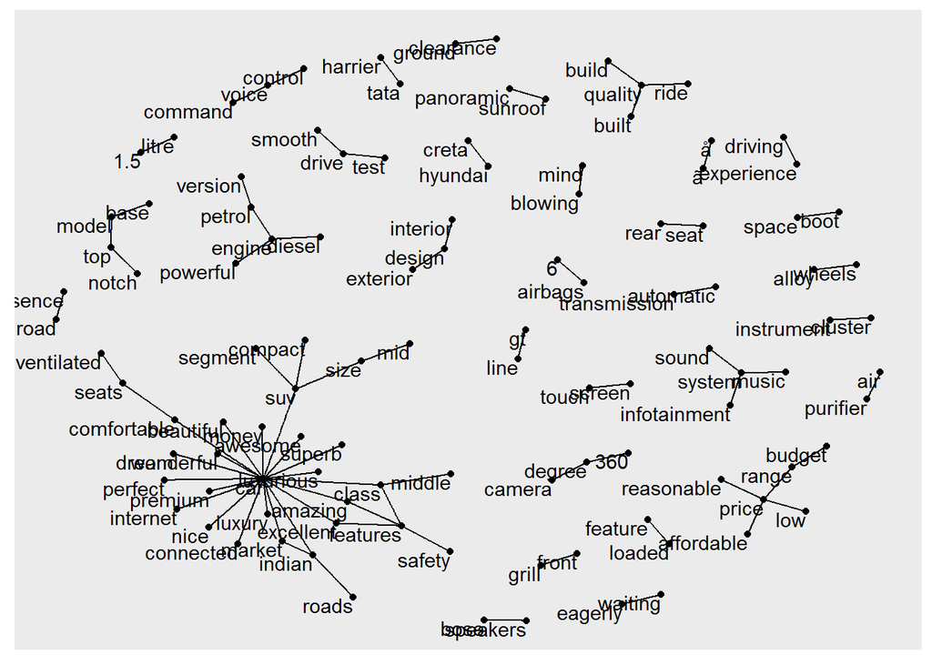

```r
#COG for all the reviews
review_bigram = create_bigram(data)

create.graph(review_bigram,10)
```

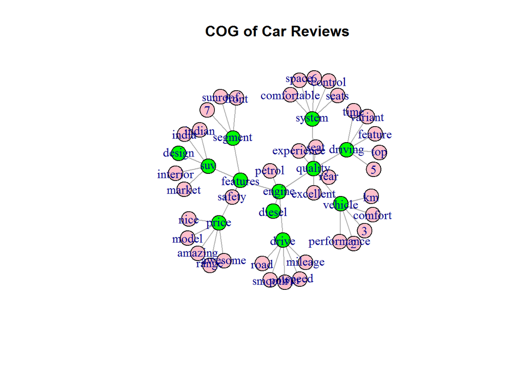

```r
distill.cog(review_dtm, 'COG of Car Reviews',12)
```

Option2: Feature extraction using Nouns or Nouns Phrases

```r
#ud_model_english <- udpipe_download_model(language = "english")

english_model = udpipe_load_model("./english-ewt-ud-2.4-190531.udpipe")

data_nlp = udpipe_annotate(english_model,x=review_df$review)

data_nlp = as.data.frame(data_nlp)
data_nlp$tag = as_phrasemachine(data_nlp$upos, type = 'upos')
head(data_nlp)
```

```
##   doc_id paragraph_id sentence_id
## 1   doc1            1           1
## 2   doc1            1           1
## 3   doc1            1           1
## 4   doc1            1           1
## 5   doc1            1           1
## 6   doc1            1           1
##                                         sentence token_id   token   lemma
## 1 great car in the suv segment and worth buying.        1   great   great
## 2 great car in the suv segment and worth buying.        2     car     car
## 3 great car in the suv segment and worth buying.        3      in      in
## 4 great car in the suv segment and worth buying.        4     the     the
## 5 great car in the suv segment and worth buying.        5     suv    sove
## 6 great car in the suv segment and worth buying.        6 segment segment
##   upos xpos                     feats head_token_id  dep_rel deps misc tag
## 1  ADJ   JJ                Degree=Pos             2     amod <NA> <NA>   A
## 2 NOUN   NN               Number=Sing             0     root <NA> <NA>   N
## 3  ADP   IN                      <NA>             6     case <NA> <NA>   P
## 4  DET   DT Definite=Def|PronType=Art             6      det <NA> <NA>   D
## 5 NOUN   NN               Number=Sing             6 compound <NA> <NA>   N
## 6 NOUN   NN               Number=Sing             2     nmod <NA> <NA>   N
```

```r
#noun_phrase = keywords_phrases(x = data_nlp$tag,term = tolower(data_nlp$token),
#                                   pattern = "(A|N)*N(P+D*(A|N)*N)*",
#                                   is_regex = TRUE, detailed = FALSE)

#noun_phrase = subset(noun_phrase,ngram>1 & freq>1)
#head(noun_phrase,20)
```

```r
data_noun = data_nlp %>% subset(., upos %in% 'NOUN')
top_noun = txt_freq(data_noun$lemma)

values = c('kia','seltos', 'mg','hector','jeep','compass')
top_noun = top_noun %>% filter(!key %in% values)

head(top_noun,20)
```

```
##           key freq   freq_pct
## 1         car 2411 11.4455258
## 2     feature  825  3.9164491
## 3       price  378  1.7944458
## 4       selto  308  1.4621410
## 5         suv  298  1.4146689
## 6        look  269  1.2769998
## 7     segment  264  1.2532637
## 8      engine  247  1.1725611
## 9     quality  225  1.0681225
## 10     design  217  1.0301448
## 11     system  163  0.7737954
## 12 experience  151  0.7168289
## 13      range  150  0.7120817
## 14       seat  147  0.6978400
## 15    vehicle  145  0.6883456
## 16    mileage  141  0.6693568
## 17   interior  138  0.6551151
## 18       road  137  0.6503679
## 19     market  133  0.6313791
## 20      drive  131  0.6218846
```

```r
data_cooc = cooccurrence(x = data_nlp$lemma,
                           relevant =  data_nlp$upos %in% c('NOUN'))

data_cooc = data_cooc %>% filter(!term1 %in% values) %>% filter(!term2 %in% values)
head(data_cooc,20)
```

```
##           term1      term2 cooc
## 1         price      range   87
## 2        safety    feature   43
## 3          boot      space   40
## 4         voice    command   33
## 5       driving experience   32
## 6          test      drive   31
## 7         touch     screen   29
## 8         build    quality   27
## 9          tata    harrier   27
## 10        sound     system   26
## 11        music     system   25
## 12       ground  clearance   25
## 13          air   purifier   23
## 14          suv        car   23
## 15         ride    quality   21
## 16       diesel     engine   21
## 17     internet        car   20
## 18        voice    control   19
## 19         road   presence   18
## 20 infotainment     system   18
```

```r
data_co = cooccurrence(x = subset(data_nlp, upos %in% c('NOUN')),
                        term = 'lemma',
                        group = c("doc_id"))
data_co = data_co %>% filter(!term1 %in% values) %>% filter(!term2 %in% values)

head(data_co,20)
```

```
##      term1      term2 cooc
## 1      car    feature 1591
## 2      car      price  639
## 3      car      selto  562
## 4      car     engine  520
## 5      car    segment  460
## 6      car     system  446
## 7      car        suv  444
## 8      car       look  439
## 9      car    quality  426
## 10     car experience  329
## 11     car     design  328
## 12     car      range  303
## 13     car       seat  302
## 14     car      drive  298
## 15     car     safety  292
## 16     car    vehicle  292
## 17     car    comfort  288
## 18     car       road  284
## 19     car      space  268
## 20 feature      price  259
```

option3: Find topics using topic modeling - LDA

```r
result = ldatuning::FindTopicsNumber(
  review_dtm,
  topics = seq(from = 2, to = 20, by = 1),
  metrics = c("Griffiths2004", "CaoJuan2009", "Arun2010", "Deveaud2014"),
  method = "Gibbs",
  control = list(seed = 77),
  mc.cores = 2L,
  verbose = TRUE
)
```

```
## fit models... done.
## calculate metrics:
##   Griffiths2004... done.
##   CaoJuan2009... done.
##   Arun2010... done.
##   Deveaud2014... done.
```

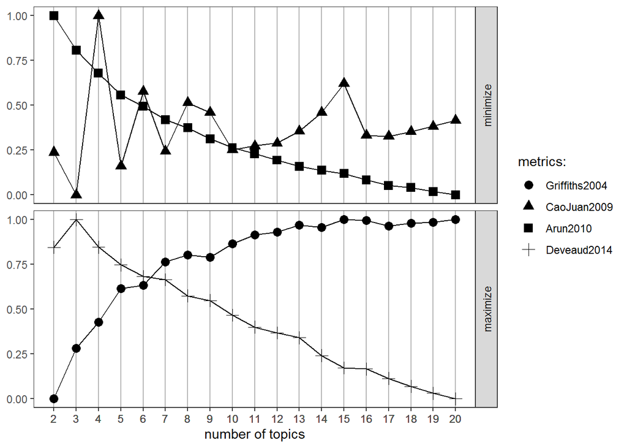

```r
ldatuning::FindTopicsNumber_plot(result)
```

```r
#find topics from consolidated data (Seltos, Jeep, Hector)
find_topics(review_dtm,12)
```

```
## # A tibble: 120 x 3
##    topic term        beta
##    <int> <chr>      <dbl>
##  1     1 sales    0.0123
##  2     1 poor     0.0115
##  3     1 version  0.0111
##  4     1 service  0.0109
##  5     1 petrol   0.0107
##  6     1 delivery 0.0101
##  7     1 brand    0.01000
##  8     1 battery  0.00956
##  9     1 2        0.00934
## 10     1 customer 0.00932
## # ... with 110 more rows
```

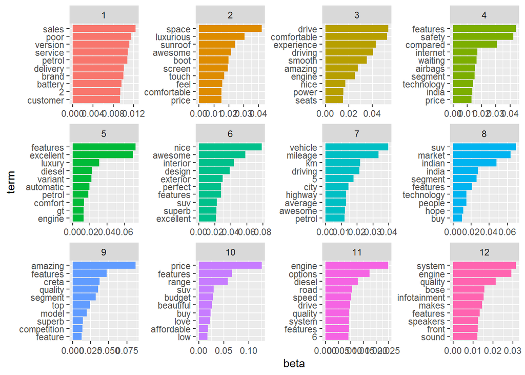

```
## # A tibble: 1,608 x 3
##    document         topic gamma
##    <chr>            <int> <dbl>
##  1 jeep compass_100     1 0.875
##  2 jeep compass_101     1 0.499
##  3 jeep compass_102     1 0.499
##  4 jeep compass_113     1 0.988
##  5 jeep compass_115     1 0.944
##  6 jeep compass_117     1 0.979
##  7 jeep compass_125     1 0.900
##  8 jeep compass_139     1 0.636
##  9 jeep compass_151     1 0.803
## 10 jeep compass_155     1 0.600
## # ... with 1,598 more rows
```

```r
#find topics from consolidated data (Seltos, Jeep, Hector)
find_topics(review_dtm,7)
```

```
## # A tibble: 70 x 3
##    topic term        beta
##    <int> <chr>      <dbl>
##  1     1 features  0.0782
##  2     1 segment   0.0397
##  3     1 suv       0.0370
##  4     1 price     0.0347
##  5     1 superb    0.0220
##  6     1 excellent 0.0190
##  7     1 range     0.0183
##  8     1 creta     0.0167
##  9     1 class     0.0165
## 10     1 market    0.0164
## # ... with 60 more rows
```

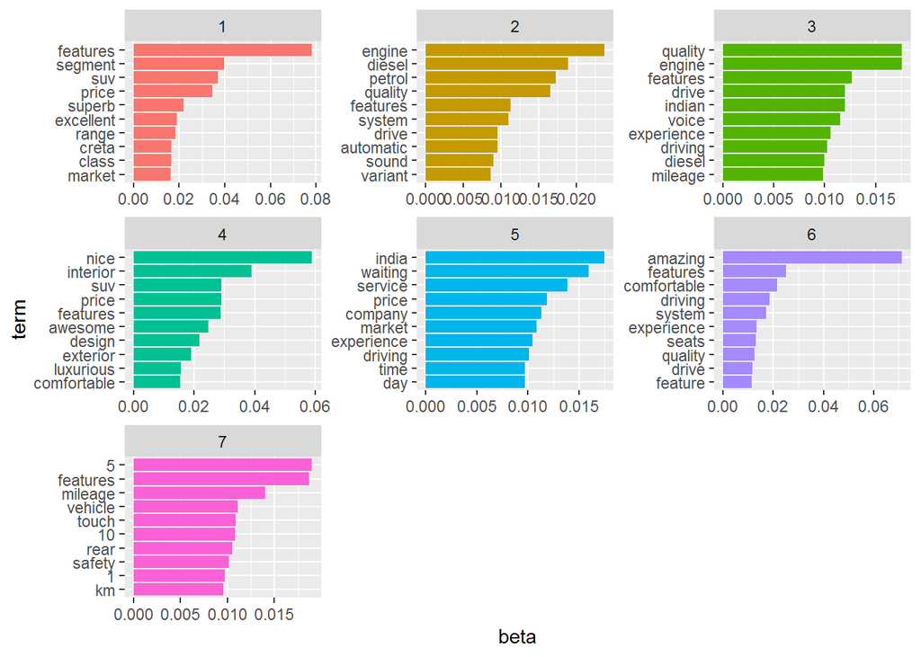

```
## # A tibble: 1,608 x 3
##    document         topic gamma
##    <chr>            <int> <dbl>
##  1 jeep compass_10      1 0.593
##  2 jeep compass_100     1 0.489
##  3 jeep compass_104     1 0.863
##  4 jeep compass_109     1 0.354
##  5 jeep compass_115     1 0.395
##  6 jeep compass_130     1 0.417
##  7 jeep compass_131     1 0.537
##  8 jeep compass_136     1 0.959
##  9 jeep compass_141     1 0.452
## 10 jeep compass_145     1 0.481
## # ... with 1,598 more rows
```

## Step 3: Choose Features/Topics

```r
keywords = c('price', 'sound', 'feature','boot','drive', 'mileage','safety','engine','design','comfort','interior', 'performance','power')
```

## Step 4: Score each document usig standard dictionary, QDAP(Princeton dictionary) & SentimentR (Lexicon & Valence shifter)

Type 1: Using Dictionary ( bing, afinn & nrc)

```r
afinn = get_sentiments("afinn")
bing =  get_sentiments("bing")
nrc = get_sentiments("nrc")
```

## Scoring using BING dictionary i.e. difference of postive & negative words in each document. Find out the average for the entire corpus

```r
#Select document based on feature
filter_doc = review_bow %>% filter(word %in% keywords)

bing_score = review_bow %>% inner_join(bing) %>% count(brand,doc_id,sentiment) %>% spread(sentiment,n,fill = 0) %>% group_by(brand,doc_id) %>% summarise(sentiment=positive-negative)
# Overall keyword based score
overall_score = inner_join(bing_score,filter_doc,by=c("brand","doc_id")) %>% group_by(brand,word) %>% summarise(cov_score = mean(sentiment)/sd(sentiment)) %>% spread(word,cov_score, fill = 0)
overall_score
```

```
## # A tibble: 3 x 14
## # Groups:   brand [3]
##   brand  boot comfort design drive engine feature interior mileage
##   <chr> <dbl>   <dbl>  <dbl> <dbl>  <dbl>   <dbl>    <dbl>   <dbl>
## 1 jeep~  0       1.25   1.04 0.904   1.16    1.05     1.08   0.214
## 2 kia ~  1.72    1.16   1.48 1.15    1.21    1.31     1.47   1.16
## 3 mg h~  1.38    1.72   1.18 1.51    1.26    1.36     1.55   1.39
## # ... with 5 more variables: performance <dbl>, power <dbl>, price <dbl>,
## #   safety <dbl>, sound <dbl>
```

```r
score_bing = bing_score %>% group_by(brand) %>% summarise(mean_Score = mean(sentiment), sd_score = sd(sentiment),cov_score = mean_Score/sd_score)
score_bing
```

```
## # A tibble: 3 x 4
##   brand        mean_Score sd_score cov_score
##   <chr>             <dbl>    <dbl>     <dbl>
## 1 jeep compass       3.24     4.62     0.701
## 2 kia seltos         4.11     3.08     1.34
## 3 mg hector          3.57     2.79     1.28
```

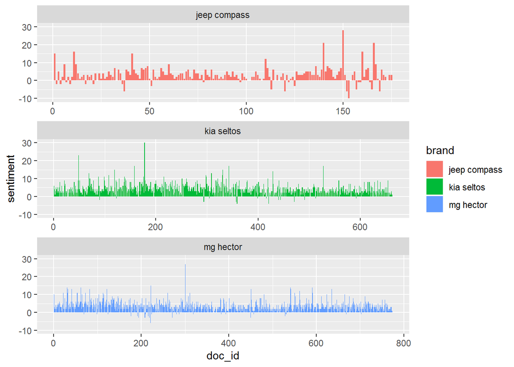

```r
ggplot(bing_score,aes(doc_id,sentiment, fill=brand))+
  geom_col()+
  facet_wrap(~brand,ncol=1,scales = "free_x")
```

## Scoring using AFINN dictionary.Find out the average for the entire corpus

```r
filter_doc = review_bow %>% filter(word %in% keywords)

affin_score = review_bow %>% inner_join(afinn) %>% group_by(brand,doc_id) %>% summarise(sentiment = sum(value))
# Overall keyword based score
overall_score = inner_join(affin_score,filter_doc,by=c("brand","doc_id")) %>% group_by(brand,word) %>% summarise(cov_score = mean(sentiment)/sd(sentiment)) %>% spread(word,cov_score, fill = 0)
overall_score
```

```
## # A tibble: 3 x 14
## # Groups:   brand [3]
##   brand  boot comfort design drive engine feature interior mileage
##   <chr> <dbl>   <dbl>  <dbl> <dbl>  <dbl>   <dbl>    <dbl>   <dbl>
## 1 jeep~  0       1.40   1.21  1.17   1.40    1.12     1.52   0.696
## 2 kia ~  1.52    1.39   1.58  1.33   1.34    1.26     1.57   1.28
## 3 mg h~  1.89    1.61   1.50  1.44   1.34    1.71     1.77   1.44
## # ... with 5 more variables: performance <dbl>, power <dbl>, price <dbl>,
## #   safety <dbl>, sound <dbl>
```

```r
score_affin = affin_score %>% group_by(brand) %>% summarise(mean_Score = mean(sentiment), sd_score = sd(sentiment),cov_score = mean_Score/sd_score)
score_affin
```

```
## # A tibble: 3 x 4
##   brand        mean_Score sd_score cov_score
##   <chr>             <dbl>    <dbl>     <dbl>
## 1 jeep compass       8.52     9.25     0.921
## 2 kia seltos         9.89     6.88     1.44
## 3 mg hector          8.87     6.14     1.45
```

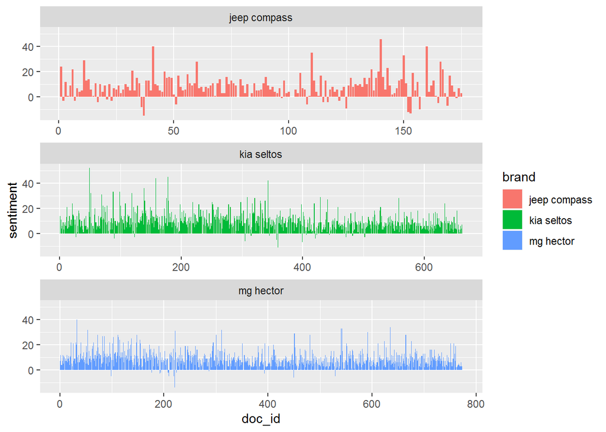

```r
ggplot(affin_score,aes(doc_id,sentiment, fill=brand))+
  geom_col()+
  facet_wrap(~brand,ncol=1,scales = "free_x")
```

## Scoring using NRC dictionary.Find out the average for the entire corpus

```r
filter_doc = review_bow %>% filter(word %in% keywords)

nrc_score = review_bow %>% inner_join(nrc) %>% count(brand,doc_id,sentiment) %>% spread(sentiment, n, fill=0) %>% group_by(brand, doc_id) %>% summarise(sentiment = positive-negative)
# Overall keyword based score
overall_score = inner_join(nrc_score,filter_doc,by=c("brand","doc_id")) %>% group_by(brand,word) %>% summarise(cov_score = mean(sentiment)/sd(sentiment)) %>% spread(word,cov_score, fill = 0)
overall_score
```

```
## # A tibble: 3 x 14
## # Groups:   brand [3]
##   brand  boot comfort design drive engine feature interior mileage
##   <chr> <dbl>   <dbl>  <dbl> <dbl>  <dbl>   <dbl>    <dbl>   <dbl>
## 1 jeep~ 0       0.834  1.41  0.687  0.893   0.932     1.43   0.842
## 2 kia ~ 1.14    1.13   1.12  1.01   1.16    1.29      1.33   1.01
## 3 mg h~ 0.898   1.71   0.845 1.29   1.00    1.33      1.27   1.09
## # ... with 5 more variables: performance <dbl>, power <dbl>, price <dbl>,
## #   safety <dbl>, sound <dbl>
```

```r
score_nrc = nrc_score %>% group_by(brand) %>% summarise(mean_Score = mean(sentiment), sd_score = sd(sentiment),cov_score = mean_Score/sd_score)
score_nrc
```

```
## # A tibble: 3 x 4
##   brand        mean_Score sd_score cov_score
##   <chr>             <dbl>    <dbl>     <dbl>
## 1 jeep compass       2.70     4.00     0.675
## 2 kia seltos         2.60     2.45     1.06
## 3 mg hector          2.46     2.43     1.01
```

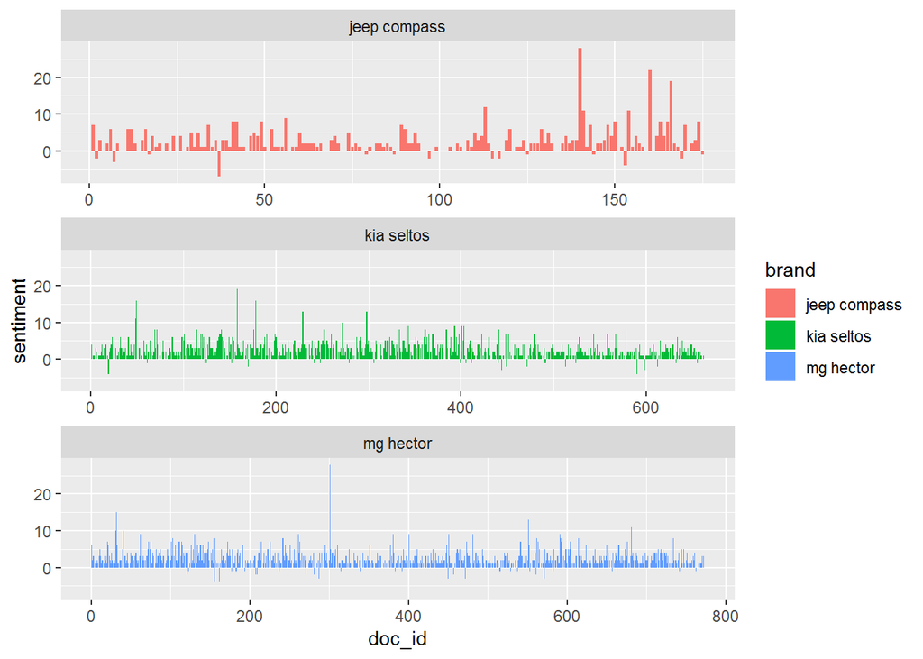

```r
ggplot(nrc_score,aes(doc_id,sentiment,fill=brand))+
  geom_col()+
  facet_wrap(~brand,ncol=1,scales = "free_x")
```

## Type 2: Polarity Score using qdap

```r
#Calculate polarity score for Kia Seltos

seltos_polarity = qdap::polarity(seltos_review)
seltos_feature_score = seltos_polarity$all %>% mutate(doc_id = row_number()) %>% select(doc_id,polarity, text.var) %>%
                unnest_tokens(word,text.var) %>% filter(word %in% keywords) %>% mutate(brand='Kia Seltos') %>%
                group_by(brand, word) %>% summarise(cov_score = mean(polarity)/sd(polarity)) %>%
                spread(word,cov_score,fill = 0)

#Calculate polarity score for Jeep Compass

compass_polarity = qdap::polarity(Compass_review)
compass_feature_score = compass_polarity$all %>% mutate(doc_id = row_number()) %>% select(doc_id,polarity, text.var) %>%
                unnest_tokens(word,text.var) %>% filter(word %in% keywords) %>% mutate(brand='Jeep Compass') %>%
                group_by(brand, word) %>% summarise(cov_score = mean(polarity)/sd(polarity)) %>%
                spread(word,cov_score,fill = 0)


#Calculate polarity score for MG Hector

hector_polarity = qdap::polarity(hector_review)
hector_feature_score = hector_polarity$all %>% mutate(doc_id = row_number()) %>% select(doc_id,polarity, text.var) %>%
                unnest_tokens(word,text.var) %>% filter(word %in% keywords) %>% mutate(brand='MG Hector') %>%
                group_by(brand, word) %>% summarise(cov_score = mean(polarity)/sd(polarity)) %>%
                spread(word,cov_score,fill = 0)


compass_qdap = data.frame(brand="Jeep Compass", mean_score = compass_polarity$group$ave.polarity, sd_score = compass_polarity$group$sd.polarity, cov_score = compass_polarity$group$stan.mean.polarity)

seltos_qdap = data.frame(brand="Kia Seltos", mean_score = seltos_polarity$group$ave.polarity, sd_score = seltos_polarity$group$sd.polarity, cov_score = seltos_polarity$group$stan.mean.polarity)

hector_qdap = data.frame(brand="MG Hector", mean_score = hector_polarity$group$ave.polarity, sd_score = hector_polarity$group$sd.polarity, cov_score = hector_polarity$group$stan.mean.polarity)


#feature-wise score
bind_rows(compass_feature_score,seltos_feature_score,hector_feature_score)
```

```
## # A tibble: 3 x 14
## # Groups:   brand [3]
##   brand  boot comfort design drive engine feature interior mileage
##   <chr> <dbl>   <dbl>  <dbl> <dbl>  <dbl>   <dbl>    <dbl>   <dbl>
## 1 Jeep~  0       2.36   1.19  1.35   1.56    2.25     1.34   0.319
## 2 Kia ~  2.15    1.87   1.97  1.57   1.43    1.39     2.05   1.55
## 3 MG H~  1.86    2.15   1.91  1.46   1.48    1.70     2.10   1.18
## # ... with 5 more variables: performance <dbl>, power <dbl>, price <dbl>,
## #   safety <dbl>, sound <dbl>
```

```r
#Cummulative score
bind_rows(compass_qdap, seltos_qdap, hector_qdap)
```

```
##          brand mean_score  sd_score cov_score
## 1 Jeep Compass  0.5199064 0.5943989 0.8746758
## 2   Kia Seltos  0.7202246 0.4815214 1.4957272
## 3    MG Hector  0.6754038 0.4650169 1.4524284
```

## Type 3: Polarity Score using sentiment (lexicon:hash_sentiment_jockers_rinker & Valence Shifter:hash_valence_shifters)

```r
#Calculate sentiment score for Kia Seltos
seltos_score = sentiment_by(seltos_review, polarity_dt = lexicon::hash_sentiment_jockers_rinker,
               valence_shifters_dt = lexicon::hash_valence_shifters)

s_score = seltos_score %>% summarise(brand = "Kia Seltos", mean_score = mean(ave_sentiment), sd_score = sd(ave_sentiment), cov_score = mean_score/sd_score)


seltos_df = review_bow %>% filter(brand=='kia seltos') %>% rename(element_id = doc_id)

seltos_final = inner_join(seltos_df,seltos_score,by='element_id')

seltos_feature_score = seltos_final %>% filter(word %in% keywords) %>% group_by(brand,word) %>%
                      summarise(cov_score = mean(ave_sentiment)/sd(ave_sentiment)) %>% spread(word,cov_score, fill = 0)

#Calculate sentiment score for Jeep Compass
compass_score = sentiment_by(Compass_review, polarity_dt = lexicon::hash_sentiment_jockers_rinker,
                valence_shifters_dt = lexicon::hash_valence_shifters)

c_score = compass_score %>% summarise(brand = "Jeep Compass", mean_score = mean(ave_sentiment), sd_score = sd(ave_sentiment), cov_score = mean_score/sd_score)


compass_df = review_bow %>% filter(brand=='jeep compass') %>% rename(element_id = doc_id)

compass_final = inner_join(compass_df,compass_score,by='element_id')

compass_feature_score = compass_final %>% filter(word %in% keywords) %>% group_by(brand,word) %>%
                      summarise(cov_score = mean(ave_sentiment)/sd(ave_sentiment)) %>% spread(word,cov_score, fill = 0)

#Calculate sentiment score for MG Hector
hector_score = sentiment_by(hector_review, polarity_dt = lexicon::hash_sentiment_jockers_rinker,
               valence_shifters_dt = lexicon::hash_valence_shifters)

h_score = hector_score %>% summarise(brand = "MG Hector", mean_score = mean(ave_sentiment), sd_score = sd(ave_sentiment), cov_score = mean_score/sd_score)


hector_df = review_bow %>% filter(brand=='mg hector') %>% rename(element_id = doc_id)

hector_final = inner_join(hector_df,hector_score,by='element_id')

hector_feature_score = hector_final %>% filter(word %in% keywords) %>% group_by(brand,word) %>%
                      summarise(cov_score = mean(ave_sentiment)/sd(ave_sentiment)) %>% spread(word,cov_score, fill = 0)



bind_rows(c_score, s_score, h_score)
```

```
##          brand mean_score  sd_score cov_score
## 1 Jeep Compass  0.2823327 0.3140786 0.8989235
## 2   Kia Seltos  0.3558169 0.2736403 1.3003091
## 3    MG Hector  0.3545921 0.2789219 1.2712950
```

```r
bind_rows(compass_feature_score,seltos_feature_score,hector_feature_score)
```

```
## # A tibble: 3 x 14
## # Groups:   brand [3]
##   brand  boot comfort design drive engine feature interior mileage
##   <chr> <dbl>   <dbl>  <dbl> <dbl>  <dbl>   <dbl>    <dbl>   <dbl>
## 1 jeep~  0       1.43   1.09  1.59  0.914    3.17     1.15   0.349
## 2 kia ~  1.68    1.90   1.42  1.36  1.23     1.38     1.70   1.24
## 3 mg h~  1.36    1.34   1.43  1.29  1.13     1.02     1.96   1.05
## # ... with 5 more variables: performance <dbl>, power <dbl>, price <dbl>,
## #   safety <dbl>, sound <dbl>
```